# APASig

Win-Vector LLC

October 2, 2016

Examples for [Proofing statistics in papers](http://www.win-vector.com/blog/2016/10/proofing-statistics-in-papers/). Uses formatting [R](https://cran.r-project.org) package sigr. Please see [here](https://web2.uconn.edu/writingcenter/pdf/Reporting_Statistics.pdf) and [here](http://my.ilstu.edu/~jhkahn/apastats.html) for some notes.

```r
library('sigr') # devtools::install_github('WinVector/sigr')
```

Example showing we can get the items reported by `summary(model)` into one well-behaved string.

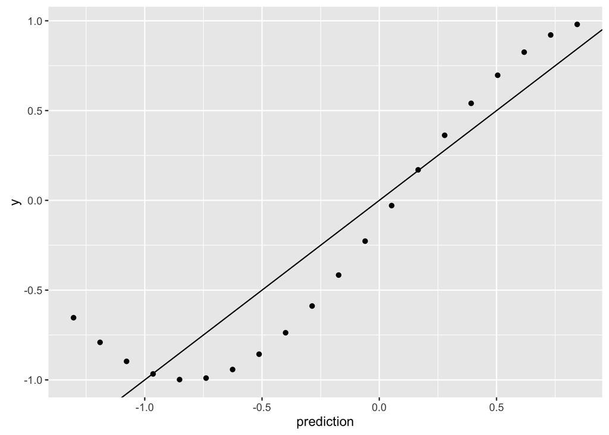

```r
library('ggplot2')
d <- data.frame(x=0.2*(1:20))
d$y <- cos(d$x)
model <- lm(y~x,data=d)
d$prediction <- predict(model,newdata=d)

ggplot(data=d,aes(x=prediction,y=y)) +
  geom_point() + geom_abline()
```

```r
print(summary(model))
```

```
##
## Call:
## lm(formula = y ~ x, data = d)
##
## Residuals:
##      Min       1Q   Median       3Q      Max
## -0.34441 -0.24493  0.00103  0.18320  0.65001
##
## Coefficients:
##             Estimate Std. Error t value Pr(>|t|)
## (Intercept)  0.95686    0.12869   7.436 6.84e-07 ***
## x           -0.56513    0.05371 -10.521 4.06e-09 ***
## ---
## Signif. codes:  0 '***' 0.001 '**' 0.01 '*' 0.05 '.' 0.1 ' ' 1
##
## Residual standard error: 0.277 on 18 degrees of freedom
## Multiple R-squared:  0.8601, Adjusted R-squared:  0.8524
## F-statistic: 110.7 on 1 and 18 DF,  p-value: 4.062e-09
```

Examples showing how to get the summary from the model.

```r
formatFTest(model,pSmallCutoff=1.0e-12)
```

$test [1] “F Test”

$numdf [1] 1

$dendf [1] 18

$FValue [1] 110.7003

$format [1] “html”

$pLargeCutoff [1] 0.05

$pSmallCutoff [1] 1e-12

$R2 [1] 0.8601402

$pValue [1] 4.062177e-09

$formatStr [1] “**F Test** summary: (*R<sup>2</sup>*=0.86, *F*(1,18)=1.1e+02, *p*=4.1e-09).”

Or frome the data.

```r
formatFTest(d,'prediction','y',
                    pSmallCutoff=1.0e-12)
```

$test [1] “F Test”

$numdf [1] 1

$dendf [1] 18

$FValue [1] 110.7003

$format [1] “html”

$pLargeCutoff [1] 0.05

$pSmallCutoff [1] 1e-12

$R2 [1] 0.8601402

$pValue [1] 4.062177e-09

$formatStr [1] “**F Test** summary: (*R<sup>2</sup>*=0.86, *F*(1,18)=1.1e+02, *p*=4.1e-09).”

Separate extracted example from https://web2.uconn.edu/writingcenter/pdf/Reporting_Statistics.pdf.

```r
formatFTestImpl(numdf=2,dendf=55,FValue=5.56)
```

$test [1] “F Test”

$numdf [1] 2

$dendf [1] 55

$FValue [1] 5.56

$format [1] “html”

$pLargeCutoff [1] 0.05

$pSmallCutoff [1] 1e-05

$R2 [1] 0.1681791

$pValue [1] 0.006321509

$formatStr [1] “**F Test** summary: (*R<sup>2</sup>*=0.17, *F*(2,55)=5.6, *p*=0.0063).”

Looks like statCheck checks the p-value, but not the R-squared.

```r
library('statcheck')
s <- statcheck('(R2=.38, F(2,55)=5.56, p < .01)')
```

```
## Extracting statistics...
```

```r
print(xtable::xtable(t(s)),type='html')
```

|  | x |
| --- | --- |
| Source | 1 |
| Statistic | F |
| df1 | 2 |
| df2 | 55 |
| Test.Comparison | = |
| Value | 5.56 |
| Reported.Comparison | < |
| Reported.P.Value | 0.01 |
| Computed | 0.006321509 |
| Raw | F(2,55)=5.56, p < .01 |
| Error | FALSE |
| DecisionError | FALSE |
| OneTail | FALSE |
| OneTailedInTxt | FALSE |
| APAfactor | 1 |

Check ours.

```r
s <- statcheck('(R2=0.17, F(2,55)=5.56, p=0.00632)')
```

```
## Extracting statistics...
```

```r
print(xtable::xtable(t(s)),type='html')
```

|  | x |
| --- | --- |
| Source | 1 |
| Statistic | F |
| df1 | 2 |
| df2 | 55 |
| Test.Comparison | = |
| Value | 5.56 |
| Reported.Comparison | = |
| Reported.P.Value | 0.00632 |
| Computed | 0.006321509 |
| Raw | F(2,55)=5.56, p=0.00632 |
| Error | FALSE |
| DecisionError | FALSE |
| OneTail | FALSE |
| OneTailedInTxt | FALSE |
| APAfactor | 1 |